# EDA 1 Variable : Problem set

Jeswin

18 September 2017

# Problem set : Explore one variable

Use these commands to load the diamonds data set.

```r
library(ggplot2) #must load the ggplot package first
suppressMessages(library(dplyr))
library(tidyr)
data(diamonds) #loads the diamonds data set since it comes with the ggplot package
suppressMessages(library(lubridate))
```

You need to run these command each time you launch RStudio to access the diamonds data set. RStudio won’t remember which packages and data sets you loaded unless you change your preferences or save your workspace.

You should notice that the diamonds data set will be listed as a **‘Promise’** in the workspace. This is a special object in R, and **you need to run a command on the data to fully load the data set. Try running a summary:** summary(diamonds)

There are other data sets that come with R. You can load these data sets by typing the command data(DATA_SET_NAME). You can learn more about the diamonds data set by typing ?diamonds. Read the help file to determine the best color for the diamonds data set. When you run diamonds$color, you will notice that the levels of color are set as D < E < F < …

This does not indicate that D is the worst color but rather an ordering to the colors.

## Qtn 1 : How many ordered factors in the dataset ?

```r
summary(diamonds)
```

```
##      carat               cut        color        clarity
##  Min.   :0.2000   Fair     : 1610   D: 6775   SI1    :13065
##  1st Qu.:0.4000   Good     : 4906   E: 9797   VS2    :12258
##  Median :0.7000   Very Good:12082   F: 9542   SI2    : 9194
##  Mean   :0.7979   Premium  :13791   G:11292   VS1    : 8171
##  3rd Qu.:1.0400   Ideal    :21551   H: 8304   VVS2   : 5066
##  Max.   :5.0100                     I: 5422   VVS1   : 3655
##                                     J: 2808   (Other): 2531
##      depth           table           price             x
##  Min.   :43.00   Min.   :43.00   Min.   :  326   Min.   : 0.000
##  1st Qu.:61.00   1st Qu.:56.00   1st Qu.:  950   1st Qu.: 4.710
##  Median :61.80   Median :57.00   Median : 2401   Median : 5.700
##  Mean   :61.75   Mean   :57.46   Mean   : 3933   Mean   : 5.731
##  3rd Qu.:62.50   3rd Qu.:59.00   3rd Qu.: 5324   3rd Qu.: 6.540
##  Max.   :79.00   Max.   :95.00   Max.   :18823   Max.   :10.740
##
##        y                z
##  Min.   : 0.000   Min.   : 0.000
##  1st Qu.: 4.720   1st Qu.: 2.910
##  Median : 5.710   Median : 3.530
##  Mean   : 5.735   Mean   : 3.539
##  3rd Qu.: 6.540   3rd Qu.: 4.040
##  Max.   :58.900   Max.   :31.800
##
```

```r
str(diamonds)
```

```
## Classes 'tbl_df', 'tbl' and 'data.frame':    53940 obs. of  10 variables:
##  $ carat  : num  0.23 0.21 0.23 0.29 0.31 0.24 0.24 0.26 0.22 0.23 ...
##  $ cut    : Ord.factor w/ 5 levels "Fair"<"Good"<..: 5 4 2 4 2 3 3 3 1 3 ...
##  $ color  : Ord.factor w/ 7 levels "D"<"E"<"F"<"G"<..: 2 2 2 6 7 7 6 5 2 5 ...
##  $ clarity: Ord.factor w/ 8 levels "I1"<"SI2"<"SI1"<..: 2 3 5 4 2 6 7 3 4 5 ...
##  $ depth  : num  61.5 59.8 56.9 62.4 63.3 62.8 62.3 61.9 65.1 59.4 ...
##  $ table  : num  55 61 65 58 58 57 57 55 61 61 ...
##  $ price  : int  326 326 327 334 335 336 336 337 337 338 ...
##  $ x      : num  3.95 3.89 4.05 4.2 4.34 3.94 3.95 4.07 3.87 4 ...
##  $ y      : num  3.98 3.84 4.07 4.23 4.35 3.96 3.98 4.11 3.78 4.05 ...
##  $ z      : num  2.43 2.31 2.31 2.63 2.75 2.48 2.47 2.53 2.49 2.39 ...
```

Hence 3 ordered factors are there.

## Qtn 2 Create a histogram of the price of all the diamonds in the diamond data set.

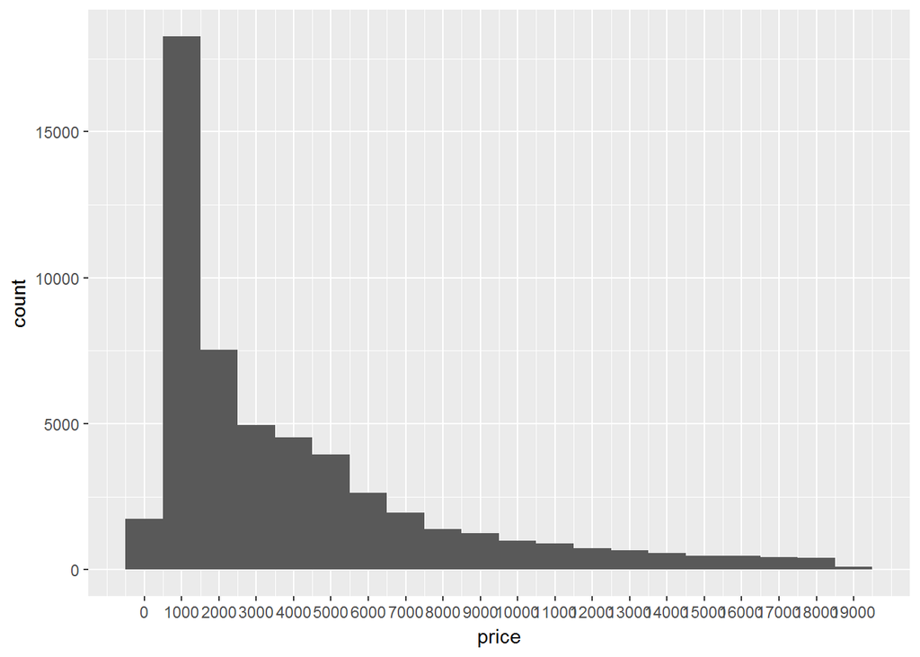

```r
qplot(data = diamonds, x = price, binwidth = 1000) +
  scale_x_continuous(breaks = seq(0,19500,1000))
```

```r
summary(diamonds$price)
```

```
##    Min. 1st Qu.  Median    Mean 3rd Qu.    Max.
##     326     950    2401    3933    5324   18823
```

## Qtn 3: How many diamonds cost less than 500, 250 and then (15000 or more)?

```r
sum(diamonds$price < 500)
```

```
## [1] 1729
```

```r
sum(diamonds$price < 250)
```

```
## [1] 0
```

```r
sum(diamonds$price >= 15000)
```

```
## [1] 1656
```

## Qtn 4 : Explore the largest peak in the price histogram you created earlier.

Try limiting the x-axis, altering the bin width and setting different breaks on the x-axis.

### You can save images by using the ggsave() command.

ggsave() will save the last plot created.

```
qplot(x = price, data = diamonds)
ggsave('priceHistogram.png')
```

ggsave currently recognises the extensions eps/ps, tex (pictex), pdf, jpeg, tiff, png, bmp, svg and wmf (windows only).

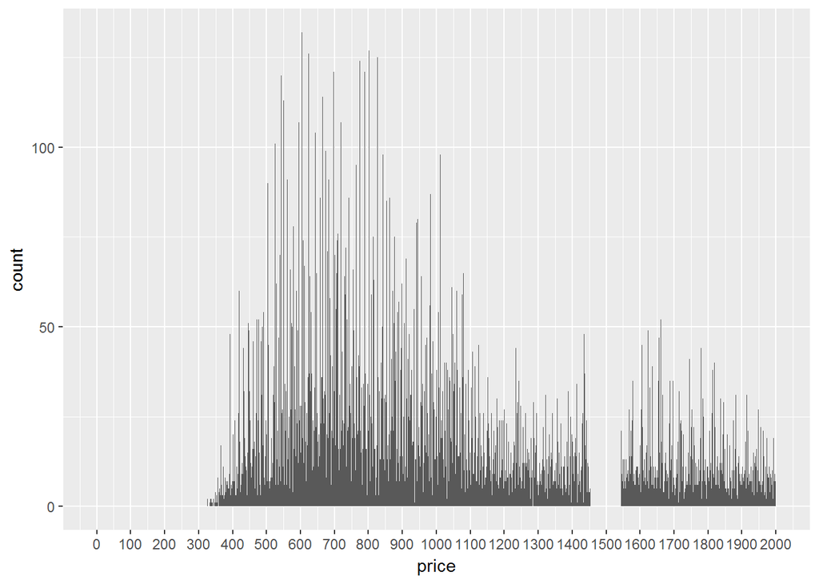

```r
qplot(data = diamonds, x = price, binwidth = 1) +
  scale_x_continuous(breaks = seq(0,2000,100), lim = c(0, 2000))
```

```r
ggsave('priceHistogram.png')
```

## Qtn 5 Price by cut histograms

Break out the histogram of diamond prices by cut. You should have five histograms in separate panels on your resulting plot.

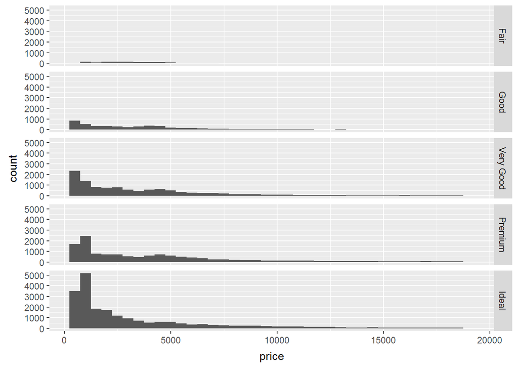

```r
qplot(data = diamonds, x = price, binwidth = 500) +
  facet_grid(cut ~ .)
```

```r
ggsave('price_cuts_Histogram.png')
by(diamonds$price, diamonds$cut, summary)
```

```
## diamonds$cut: Fair
##    Min. 1st Qu.  Median    Mean 3rd Qu.    Max.
##     337    2050    3282    4359    5206   18574
## --------------------------------------------------------
## diamonds$cut: Good
##    Min. 1st Qu.  Median    Mean 3rd Qu.    Max.
##     327    1145    3050    3929    5028   18788
## --------------------------------------------------------
## diamonds$cut: Very Good
##    Min. 1st Qu.  Median    Mean 3rd Qu.    Max.
##     336     912    2648    3982    5373   18818
## --------------------------------------------------------
## diamonds$cut: Premium
##    Min. 1st Qu.  Median    Mean 3rd Qu.    Max.
##     326    1046    3185    4584    6296   18823
## --------------------------------------------------------
## diamonds$cut: Ideal
##    Min. 1st Qu.  Median    Mean 3rd Qu.    Max.
##     326     878    1810    3458    4678   18806
```

## Qtn 6

### Which cut has highest priced diamond?

Ans: Diamond cut : Premium : 18823

### Which cut has lowest priced diamond?

Ans: Diamond cut : Premium and Ideal : 326

### Scales and Multiple histograms

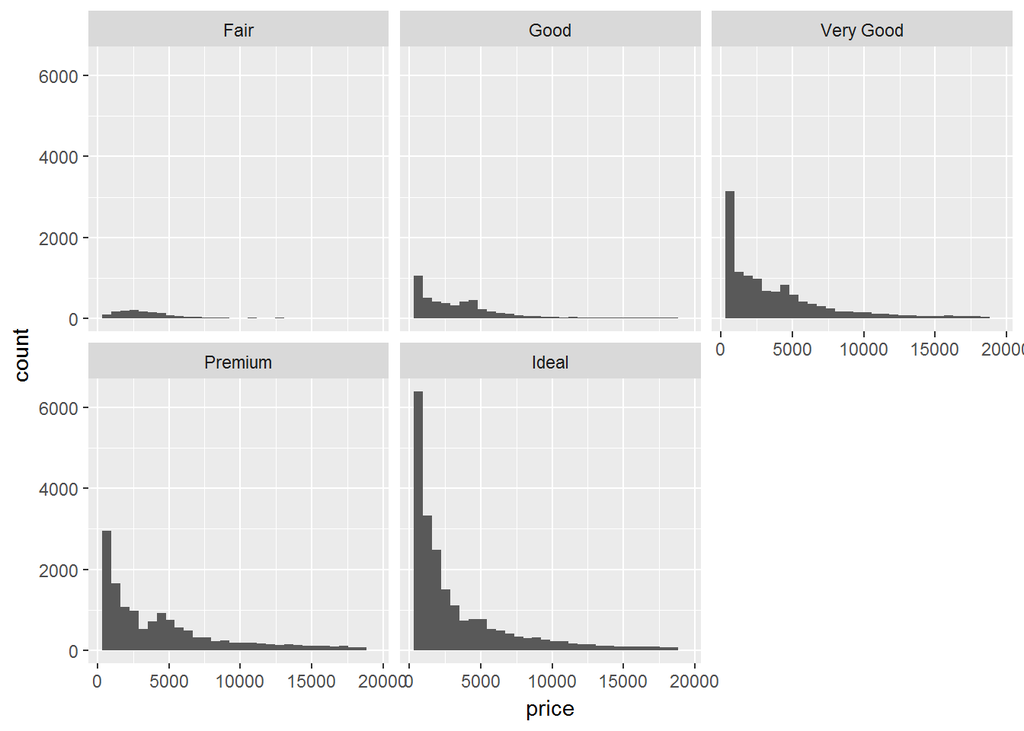

```r
qplot(x = price, data = diamonds) + facet_wrap(~cut)
```

The ‘Fair’ and ‘Good’ diamonds appear to have different distributions compared to the better cut diamonds. They seem somewhat uniform on the left with long tails on the right. Let’s look in to this more. Look up the documentation for facet_wrap in R Studio. Then, scroll back up and add a parameter to facet_wrap so that the y-axis in the histograms is not fixed. You want the y-axis to be different for each histogram.

### Qtn 8 : Scales and Multiple Histograms

It’s a good idea to consider the scales when you create plots.

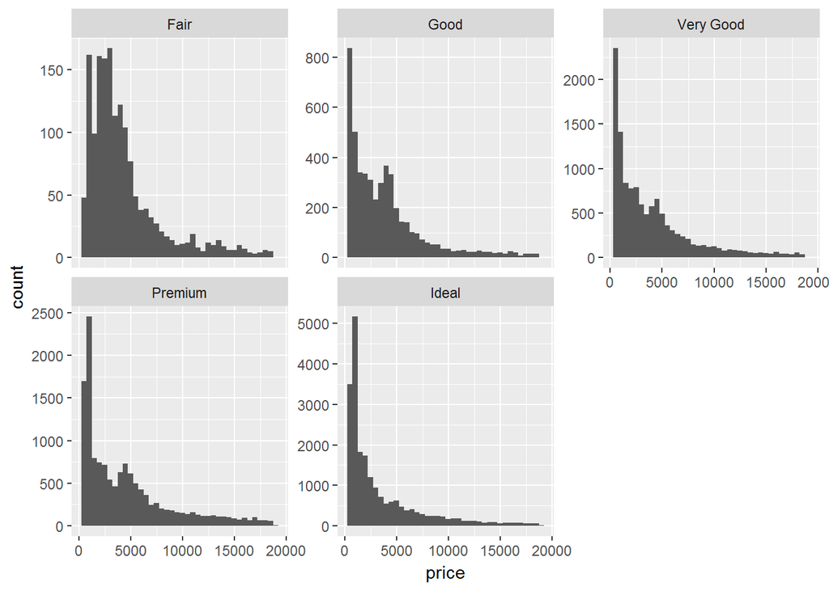

```r
qplot(x = price, data = diamonds, binwidth = 500) +
  facet_wrap( ~ cut, scales = "free_y")
```

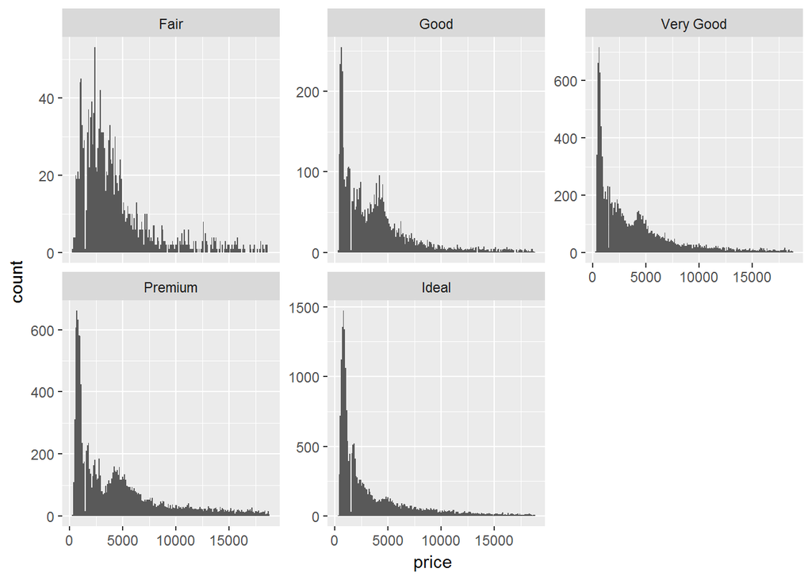

```r
ggplot(aes(x=price), data = diamonds)+
  geom_histogram(binwidth = 100, limits = c(0,18000))+
  facet_wrap( ~ cut, scales = 'free_y')
```

### Qtn 9 : Price per Carat by Cut

Create a histogram of price per carat and facet it by cut. You can make adjustments to the code from the previous exercise to get started. Adjust the bin width and transform the scale of the x-axis using log10.

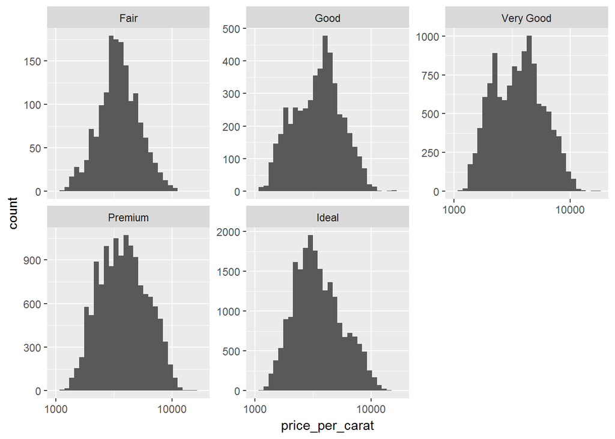

```r
diamonds$price_per_carat <- diamonds$price/diamonds$carat
ggplot(data = diamonds, aes(x = price_per_carat))+
  geom_histogram()+
  scale_x_log10()+
  facet_wrap( ~ cut, scales = "free_y")
```

### Qtn 10 : Price Box plots

Investigate the price of diamonds using box plots, numerical summaries, and one of the following categorical variables: cut, clarity, or color.

**Boxplot using cut and prices**

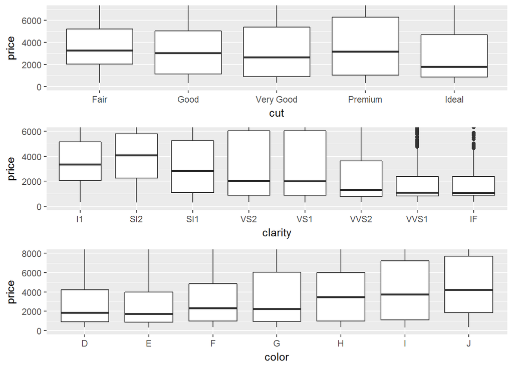

```r
p1_cut <- ggplot(data = diamonds, aes(x = cut, y = price)) +
  geom_boxplot() +
  coord_cartesian(ylim = c(0,7000))

p2_clarity  <- ggplot(data = diamonds, aes(x = clarity, y = price)) +
  geom_boxplot() +
  coord_cartesian(ylim = c(0,6000))


p3_color <- ggplot(data = diamonds, aes(x = color, y = price)) +
  geom_boxplot()+
  coord_cartesian(ylim = c(0, 8000))

library(gridExtra)
library(grid)

grid.arrange(p1_cut, p2_clarity, p3_color, ncol = 1)
```

```r
ggsave('boxplot_compilation.png')
```

## Qtn 11 : Interquartile Range - IQR

You can use the function IQR() to find the interquartile range. Pass it a subset of the diamonds data frame.

For example:

```
IQR(subset(diamonds, price <1000)$price)
```

Remember that subset() returns a data frame so we need to use $price on the end to access that variable.

### Price range for middle for middle 50% of diamonds with color D?

```r
summary(subset(diamonds, color == 'D')$price)
```

```
##    Min. 1st Qu.  Median    Mean 3rd Qu.    Max.
##     357     911    1838    3170    4214   18693
```

```r
IQR(subset(diamonds, color == 'D')$price)
```

```
## [1] 3302.5
```

### Price range for middle for middle 50% of diamonds with color J?

```r
summary(subset(diamonds, color == 'J')$price)
```

```
##    Min. 1st Qu.  Median    Mean 3rd Qu.    Max.
##     335    1860    4234    5324    7695   18710
```

```r
IQR(subset(diamonds, color == 'J')$price)
```

```
## [1] 5834.5
```

```r
summary(subset(diamonds, color == 'E')$price)
```

```
##    Min. 1st Qu.  Median    Mean 3rd Qu.    Max.
##     326     882    1739    3077    4003   18731
```

```r
summary(subset(diamonds, color == 'I')$price)
```

```
##    Min. 1st Qu.  Median    Mean 3rd Qu.    Max.
##     334    1120    3730    5092    7202   18823
```

### Qtn 12. Price per Carat Box Plots by Color

Investigate the price per carat of diamonds across the different colors of diamonds using boxplots.

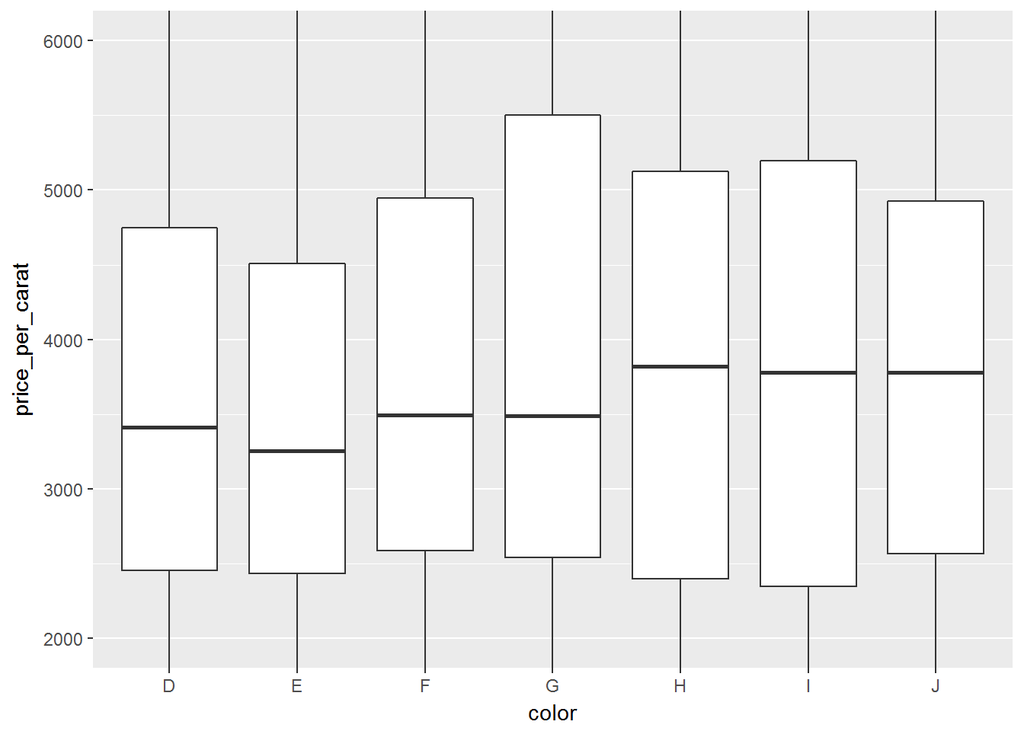

```r
ggplot(data = diamonds, aes(x = color, y = price_per_carat))+
  geom_boxplot()+
  coord_cartesian(ylim = c(2000,6000))
```

### Qtn 13: Carat Frequency Polygon

Investigate the weight of the diamonds (carat) using a frequency polygon. Use different **binwidths** to see how the frequency polygon changes. What carat size has a count greater than 2000?

qplot(data = diamonds, x = price, binwidth = 1) + scale_x_continuous(breaks = seq(0,2000,100), lim = c(0, 2000))

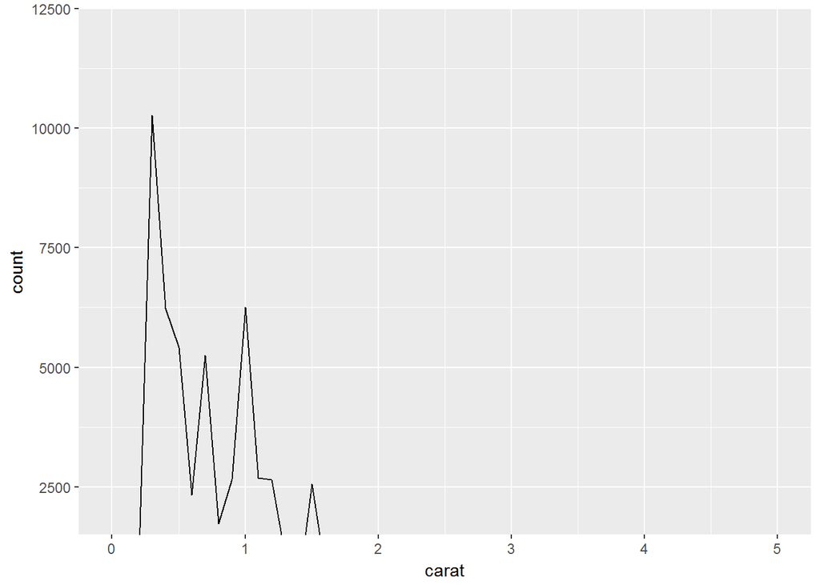

```r
ggplot(data = diamonds, aes(x = carat)) +
  geom_freqpoly(binwidth = 0.1) +
  scale_x_continuous(breaks = seq(0,5,1), lim = c(0,5))+
  coord_cartesian(ylim = c(2000,12000))
```

**Try adjusting the bin width; a too-large bin size might lead you to believe that some carat weights occur more often than they actually do in the data**. You might also want to look at a **table()** of counts to help focus down on an answer.

```r
table(diamonds$carat)
```

```
##
##  0.2 0.21 0.22 0.23 0.24 0.25 0.26 0.27 0.28 0.29  0.3 0.31 0.32 0.33 0.34
##   12    9    5  293  254  212  253  233  198  130 2604 2249 1840 1189  910
## 0.35 0.36 0.37 0.38 0.39  0.4 0.41 0.42 0.43 0.44 0.45 0.46 0.47 0.48 0.49
##  667  572  394  670  398 1299 1382  706  488  212  110  178   99   63   45
##  0.5 0.51 0.52 0.53 0.54 0.55 0.56 0.57 0.58 0.59  0.6 0.61 0.62 0.63 0.64
## 1258 1127  817  709  625  496  492  430  310  282  228  204  135  102   80
## 0.65 0.66 0.67 0.68 0.69  0.7 0.71 0.72 0.73 0.74 0.75 0.76 0.77 0.78 0.79
##   65   48   48   25   26 1981 1294  764  492  322  249  251  251  187  155
##  0.8 0.81 0.82 0.83 0.84 0.85 0.86 0.87 0.88 0.89  0.9 0.91 0.92 0.93 0.94
##  284  200  140  131   64   62   34   31   23   21 1485  570  226  142   59
## 0.95 0.96 0.97 0.98 0.99    1 1.01 1.02 1.03 1.04 1.05 1.06 1.07 1.08 1.09
##   65  103   59   31   23 1558 2242  883  523  475  361  373  342  246  287
##  1.1 1.11 1.12 1.13 1.14 1.15 1.16 1.17 1.18 1.19  1.2 1.21 1.22 1.23 1.24
##  278  308  251  246  207  149  172  110  123  126  645  473  300  279  236
## 1.25 1.26 1.27 1.28 1.29  1.3 1.31 1.32 1.33 1.34 1.35 1.36 1.37 1.38 1.39
##  187  146  134  106  101  122  133   89   87   68   77   50   46   26   36
##  1.4 1.41 1.42 1.43 1.44 1.45 1.46 1.47 1.48 1.49  1.5 1.51 1.52 1.53 1.54
##   50   40   25   19   18   15   18   21    7   11  793  807  381  220  174
## 1.55 1.56 1.57 1.58 1.59  1.6 1.61 1.62 1.63 1.64 1.65 1.66 1.67 1.68 1.69
##  124  109  106   89   89   95   64   61   50   43   32   30   25   19   24
##  1.7 1.71 1.72 1.73 1.74 1.75 1.76 1.77 1.78 1.79  1.8 1.81 1.82 1.83 1.84
##  215  119   57   52   40   50   28   17   12   15   21    9   13   18    4
## 1.85 1.86 1.87 1.88 1.89  1.9 1.91 1.92 1.93 1.94 1.95 1.96 1.97 1.98 1.99
##    3    9    7    4    4    7   12    2    6    3    3    4    4    5    3
##    2 2.01 2.02 2.03 2.04 2.05 2.06 2.07 2.08 2.09  2.1 2.11 2.12 2.13 2.14
##  265  440  177  122   86   67   60   50   41   45   52   43   25   21   48
## 2.15 2.16 2.17 2.18 2.19  2.2 2.21 2.22 2.23 2.24 2.25 2.26 2.27 2.28 2.29
##   22   25   18   31   22   32   23   27   13   16   18   15   12   20   17
##  2.3 2.31 2.32 2.33 2.34 2.35 2.36 2.37 2.38 2.39  2.4 2.41 2.42 2.43 2.44
##   21   13   16    9    5    7    8    6    8    7   13    5    8    6    4
## 2.45 2.46 2.47 2.48 2.49  2.5 2.51 2.52 2.53 2.54 2.55 2.56 2.57 2.58 2.59
##    4    3    3    9    3   17   17    9    8    9    3    3    3    3    1
##  2.6 2.61 2.63 2.64 2.65 2.66 2.67 2.68  2.7 2.71 2.72 2.74 2.75 2.77  2.8
##    3    3    3    1    1    3    1    2    1    1    3    3    2    1    2
##    3 3.01 3.02 3.04 3.05 3.11 3.22 3.24  3.4  3.5 3.51 3.65 3.67    4 4.01
##    8   14    1    2    1    1    1    1    1    1    1    1    1    1    2
## 4.13  4.5 5.01
##    1    1    1
```

## Doing the problem programmatically

it is pretty hard to read from a frequency polygon plot all the carats bins over 2000 counts.

What I did was to check the carat variable first, and not notice that the minimum interval between carat values was 0.01 (that is the precision of the carat values in the data set). Then I did:

```r
carats <- as.data.frame(table(diamonds$carat))
carats[carats$Freq > 2000, ]
```

```
##    Var1 Freq
## 11  0.3 2604
## 12 0.31 2249
## 82 1.01 2242
```

Another way is to use the table function:

```
with(diamonds, table(carat)[table(carat) > 2000])
```

```r
with(diamonds, table(carat)[table(carat) > 2000])
```

```
## carat
##  0.3 0.31 1.01
## 2604 2249 2242
```

That statement broken down: 1. **with(diamonds, )**

This part just means that you don’t have to refer to the dataframe in the ‘table’ part. That is, you don’t have to use:

```
diamonds$carat
```

2. table

The ‘table’ part creates a frequency table (or table of counts for each variable)

You can get more detail on ‘table’ if you type:

**?table**

in the console in RStudio.

3. **[table(carat)>2000]**

This limits the table to the values that have a count greater than 2000.

You can see the effect if you run:

```
table(diamonds$carat)
table(diamonds$carat)[table(diamonds$carat) > 2000]
```

as two separate statements.

### Data Wrangling with R

Data munging or data wrangling can take up much of a data scientist’s or data analyst’s time. There are two R packages that make these tasks easier in R: tidyr and dplyr.

tidyr -a package that reshapes the layout of your data

dplyr - a package that helps you transform tidy, tabular data

Review [Data Wrangling in R](https://s3.amazonaws.com/udacity-hosted-downloads/ud651/DataWranglingWithR.pdf) to get a sense of how these packages allow you to manipulate data. You can use these packages to help you in the next programming task and in your future investigations.

There are some useful cheat sheets on [RStudio’s webpage](http://www.rstudio.com/resources/cheatsheets/).

The [Data Import](https://github.com/rstudio/cheatsheets/raw/master/source/pdfs/data-import-cheatsheet.pdf) and [Data Transformation](https://github.com/rstudio/cheatsheets/raw/master/source/pdfs/data-transformation-cheatsheet.pdf) sheets will be good references for working with tidyr and dplyr, respectively.

# [Reading data from excel files](http://www.sthda.com/english/wiki/reading-data-from-excel-files-xls-xlsx-into-r)

IMP WEBSITE LINK ABOVE

## method 1 :On Windows system

Open the Excel file containing your data: select and copy the data (ctrl + c)

Type the R code below to import the copied data from the clipboard into R and store the data in a data frame (my_data)

```
my_data <- read.table(file = "clipboard",
                      sep = "\t", header=TRUE)
```

## Method 2: Importing Excel files into R using readxl package

The readxl package, developed by Hadley Wickham, can be used to easily import Excel files (xls|xlsx) into R without any external dependencies.

```
install.packages("readxl"
library("readxl")
```

### Read both xls and xlsx files

```
# Loading
library("readxl")
# xls files
my_data <- read_excel("my_file.xls")
# xlsx files
my_data <- read_excel("my_file.xlsx")
```

### Specify sheet with a number or name

```
# Specify sheet by its name
my_data <- read_excel("my_file.xlsx", sheet = "data")

# Specify sheet by its index
my_data <- read_excel("my_file.xlsx", sheet = 2)
```

### Case of missing values: NA (not available). If NAs are represented by something (example: “-”) other than blank cells, set the na argument:

```
my_data <- read_excel("my_file.xlsx", na = "---")
```

## Importing Excel files using xlsx package

The xlsx package, a java-based solution, is one of the powerful R packages to read, write and format Excel files.

### Installing and loading xlsx package

```
install.packages("xlsx")
library("xlsx")
```

### Using xlsx package

There are two main functions in xlsx package for reading both xls and xlsx Excel files: read.xlsx() and read.xlsx2() [faster on big files compared to read.xlsx function].

The simplified formats are:

```
read.xlsx(file, sheetIndex, header=TRUE)
read.xlsx2(file, sheetIndex, header=TRUE)
```

### Quiz 15 : Gapminder Data

[Gapminder Data](http://www.gapminder.org/data/) : Aged 15-24 employment rate (%)

The following command may be helpful for some of the Gapminder Data sets, once it’s been converted to csv format:

**read.csv(‘data.csv’, header = T, row.names = 1, check.names = F)**

You may want to look at additional function arguments in the help file for the read.table() family for additional tools that can help you read in data.

If you want to exchange the rows and columns of your dataframe, it will also be useful to know the transpose function, **t()**

The Gapminder website contains over 500 data sets with information about the world’s population. Your task is to download a data set of your choice and create 2-5 plots that make use of the techniques from Lesson 3.

You might use a simple histogram, a boxplot split over a categorical variable, or a frequency polygon. The choice is yours!

```r
emprate <- read.csv("indicator_t 15-24 employ.csv",header = T, row.names = 1, check.names = F)
head(emprate)
```

```
##             1991 1992 1993 1994 1995 1996 1997 1998 1999 2000 2001 2002
## Afghanistan 50.4 50.2 50.4 50.0 50.0 50.0 50.1 50.1 50.1 50.2 50.8 50.6
## Albania     38.9 38.5 38.6 38.8 38.8 38.2 38.4 38.1 37.7 37.4 37.0 36.8
## Algeria     25.4 24.7 25.2 25.1 23.7 24.6 25.3 24.8 24.3 23.2 24.9 25.7
## Angola      69.1 68.5 69.0 68.9 69.9 69.9 69.5 69.1 68.9 68.9 68.8 68.7
## Argentina   42.9 43.3 43.3 43.8 43.5 44.0 44.0 43.3 42.3 42.2 41.3 40.0
## Armenia     23.8 21.6 21.0 22.5 21.4 22.3 21.9 22.2 22.0 22.9 23.9 24.2
##             2003 2004 2005 2006 2007
## Afghanistan 47.8 50.0 45.9 48.8 48.0 NA
## Albania     36.4 35.9 35.5 35.2 35.6 NA
## Algeria     26.9 31.0 32.5 34.8 34.0 NA
## Angola      68.4 68.3 68.1 67.5 67.7 NA
## Argentina   41.3 40.7 40.0 39.4 39.0 NA
## Armenia     24.5 24.0 24.1 23.8 25.6 NA
```

```r
emprate <- emprate[1:178,1:17]   # Used slicing to remove NA column (179) and row(18)
dim(emprate)
```

```
## [1] 178  17
```

Taking transpose of the dataframe. And from the transposed dataframe selct the countries(column names) whose employement rate i am interested in finding.

```r
emprate <- data.frame(t(emprate))
dfemprate <- emprate[ , c("Bangladesh", "India", "Germany", "Japan", "United.Kingdom", "United.States", "Russia", "Pakistan")]
head(dfemprate)
```

```
##      Bangladesh India Germany Japan United.Kingdom United.States Russia
## 1991       66.6  47.3    57.8  43.1           65.9          56.1   34.3
## 1992       61.9  47.6    55.4  44.4           60.8          55.5   35.2
## 1993       63.8  46.4    52.8  44.7           58.0          56.1   36.6
## 1994       61.4  45.3    51.2  44.9           58.0          57.1   36.1
## 1995       58.3  46.5    49.2  44.7           58.3          57.5   36.8
## 1996       59.3  46.2    47.5  44.9           59.7          57.1   33.9
##      Pakistan
## 1991     38.5
## 1992     39.1
## 1993     38.0
## 1994     37.9
## 1995     35.9
## 1996     36.6
```

```r
years <- factor(rownames(dfemprate), labels = c(1991:2007) )
dfemprate <- cbind(years, dfemprate)
head(dfemprate)
```

```
##      years Bangladesh India Germany Japan United.Kingdom United.States
## 1991  1991       66.6  47.3    57.8  43.1           65.9          56.1
## 1992  1992       61.9  47.6    55.4  44.4           60.8          55.5
## 1993  1993       63.8  46.4    52.8  44.7           58.0          56.1
## 1994  1994       61.4  45.3    51.2  44.9           58.0          57.1
## 1995  1995       58.3  46.5    49.2  44.7           58.3          57.5
## 1996  1996       59.3  46.2    47.5  44.9           59.7          57.1
##      Russia Pakistan
## 1991   34.3     38.5
## 1992   35.2     39.1
## 1993   36.6     38.0
## 1994   36.1     37.9
## 1995   36.8     35.9
## 1996   33.9     36.6
```

First loading the tidyr package Using gather() command:

```r
library(tidyr)
country_emp <- gather(dfemprate,key = countries, value = Emp_rate, Bangladesh, India, Germany, Japan, United.Kingdom, United.States, Russia,Pakistan)
head(country_emp)
```

```
##   years  countries Emp_rate
## 1  1991 Bangladesh     66.6
## 2  1992 Bangladesh     61.9
## 3  1993 Bangladesh     63.8
## 4  1994 Bangladesh     61.4
## 5  1995 Bangladesh     58.3
## 6  1996 Bangladesh     59.3
```

### My qtns : Finding employement rate of different countries from 1991 to 2007

## Creating boxplot

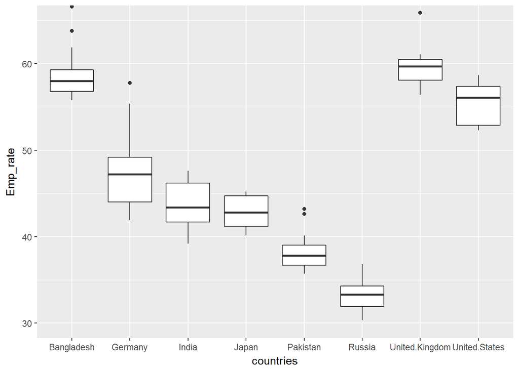

```r
ggplot(data = country_emp, aes(x = countries, y = Emp_rate)) +
  geom_boxplot()+
  coord_cartesian(ylim = c(30,65))+
  ggsave('boxplot.png')
```

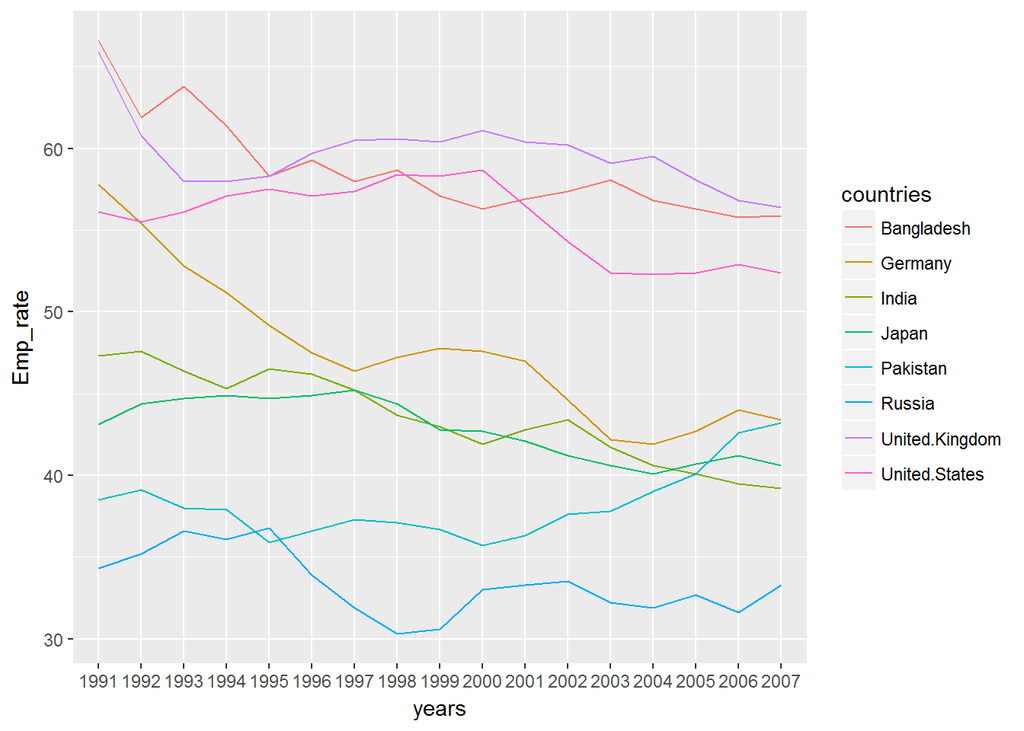

```r
ggplot(data = country_emp, aes(x=years, y=Emp_rate, group = countries, colour = countries))+
  geom_line()+
  ggsave('scatr.png')
```

## Quiz 16 : Exploring friends bday

Once you load the data into R Studio, you can use the strptime() function to extract the birth months and birth days. We recommend looking up the documentation for the function and finding examples online. Once you’ve completed your investigation, create a post in the discussions that includes: 1. any questions you answered, your observations, and summary statistics 2. snippets of code that created the plots 3. links to the images of your plots

### Qtns:

- Which month contains the most number of birthdays?
- How many birthdays are in each month?
- Which day of the year has the most number of birthdays?
- Do you have at least 365 friends that have birthdays on everyday of the year??

```r
bday_list_df <- read.csv("birthdaysExample.csv",stringsAsFactors = FALSE)
bday_list_df$dates[1:5]
```

```
## [1] "11/25/14" "6/8/14"   "9/12/14"  "5/26/14"  "2/20/14"
```

```r
a <- bday_list_df$dates[1:5]
```

```r
bday_list_df$dates <- strptime(bday_list_df$dates, "%m/%d/%y")
```

```r
bday_list_df$dates[1:5]
```

```
## [1] "2014-11-25 IST" "2014-06-08 IST" "2014-09-12 IST" "2014-05-26 IST"
## [5] "2014-02-20 IST"
```

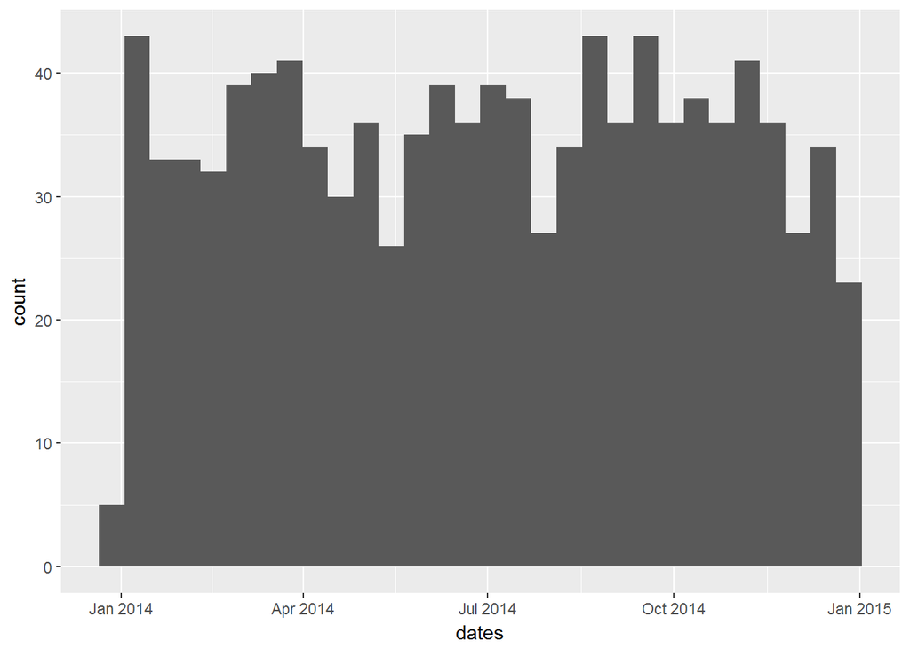

```r
ggplot(data = bday_list_df, aes(x = dates))+
  geom_histogram()
```

## New trials using lubridate

```r
bday_list_df <- read.csv("birthdaysExample.csv",stringsAsFactors = FALSE)
head(bday_list_df)
```

```
##      dates
## 1 11/25/14
## 2   6/8/14
## 3  9/12/14
## 4  5/26/14
## 5  2/20/14
## 6  6/19/14
```

```r
str(bday_list_df)
```

```
## 'data.frame':    1033 obs. of  1 variable:
##  $ dates: chr  "11/25/14" "6/8/14" "9/12/14" "5/26/14" ...
```

```r
bday_list_df$dates <- mdy(bday_list_df$dates)
str(bday_list_df)
```

```
## 'data.frame':    1033 obs. of  1 variable:
##  $ dates: Date, format: "2014-11-25" "2014-06-08" ...
```

```r
head(bday_list_df)
```

```
##        dates
## 1 2014-11-25
## 2 2014-06-08
## 3 2014-09-12
## 4 2014-05-26
## 5 2014-02-20
## 6 2014-06-19
```

#### Creating three new columns with day, month and year

```r
bday_list_df$Day <- day(bday_list_df$dates)
bday_list_df$Month <- month(bday_list_df$dates)
bday_list_df$Year <- year(bday_list_df$dates)
head(bday_list_df)
```

```
##        dates Day Month Year
## 1 2014-11-25  25    11 2014
## 2 2014-06-08   8     6 2014
## 3 2014-09-12  12     9 2014
## 4 2014-05-26  26     5 2014
## 5 2014-02-20  20     2 2014
## 6 2014-06-19  19     6 2014
```

### To check how many of many friends have same birthday as mine?

```r
same_bday <- filter(bday_list_df, Day == 22 & Month == 11)
nrow(same_bday)
```

```
## [1] 2
```

### Which month contains the most number of birthdays?

```r
# Converting 1 to 12 numbers as factors
bday_list_df$ofMonth <- ordered(bday_list_df$Month, levels = c(1:12))
str(bday_list_df)
```

```
## 'data.frame':    1033 obs. of  5 variables:
##  $ dates  : Date, format: "2014-11-25" "2014-06-08" ...
##  $ Day    : int  25 8 12 26 20 19 10 22 6 20 ...
##  $ Month  : num  11 6 9 5 2 6 10 10 7 9 ...
##  $ Year   : num  2014 2014 2014 2014 2014 ...
##  $ ofMonth: Ord.factor w/ 12 levels "1"<"2"<"3"<"4"<..: 11 6 9 5 2 6 10 10 7 9 ...
```

```r
head(bday_list_df)
```

```
##        dates Day Month Year ofMonth
## 1 2014-11-25  25    11 2014      11
## 2 2014-06-08   8     6 2014       6
## 3 2014-09-12  12     9 2014       9
## 4 2014-05-26  26     5 2014       5
## 5 2014-02-20  20     2 2014       2
## 6 2014-06-19  19     6 2014       6
```

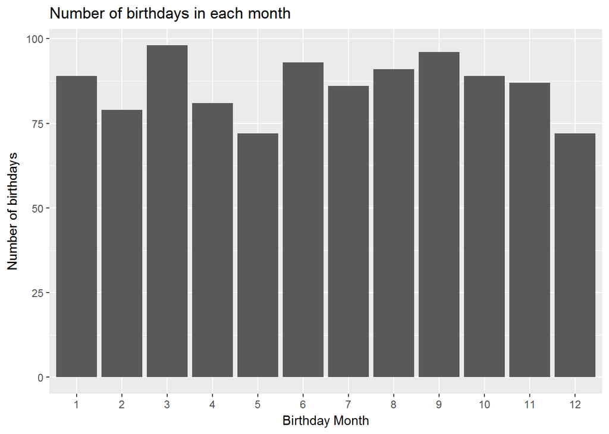

```r
ggplot(data = bday_list_df, aes(x = ofMonth)) +
  geom_bar()+
  labs(x = "Birthday Month", y = "Number of birthdays", title = "Number of birthdays in each month")
```

**Using table()**

```r
table(bday_list_df$ofMonth)
```

```
##
##  1  2  3  4  5  6  7  8  9 10 11 12
## 89 79 98 81 72 93 86 91 96 89 87 72
```

### How many birthdays are in each month?

```r
bday_list_df %>%
  group_by(ofMonth) %>%
  summarise(Bdays_each_month = n())
```

```
## # A tibble: 12 x 2
##    ofMonth Bdays_each_month
##      <ord>            <int>
##  1       1               89
##  2       2               79
##  3       3               98
##  4       4               81
##  5       5               72
##  6       6               93
##  7       7               86
##  8       8               91
##  9       9               96
## 10      10               89
## 11      11               87
## 12      12               72
```

### Do you have at least 365 friends that have birthdays on everyday of the year??

```r
bdays <- bday_list_df %>%
  select(Day,Month)

uniq_bdays <- unique(bdays)
nrow(uniq_bdays)
```

```
## [1] 348
```